# Network Analysis : London Tube

# Communities

Below we show the visualization of communities formed using the `Walktap Community` and `Edge Betweenness Community`.

Walktrap Community is an approach based on random walks. The general idea is that if you perform random walks on the graph, then the walks are more likely to stay within the same community because there are only a few edges that lead outside a given community.

Edge Betweenness Community is a hierarchical decomposition process where edges are removed in the decreasing order of their edge betweenness scores (i.e. the number of shortest paths that pass through a given edge).

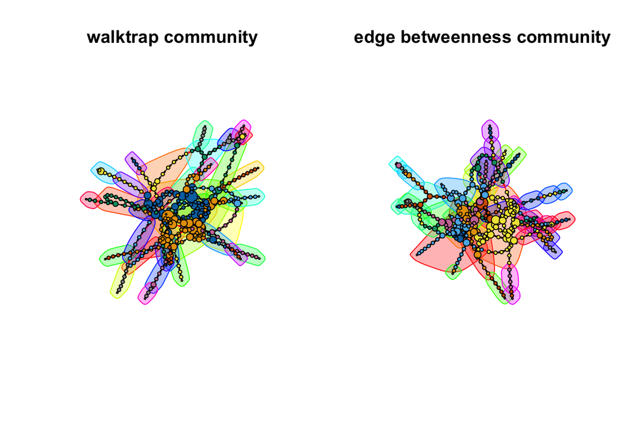

We will also analysie Modularity, It is one measure of the structure of networks or graphs. It was designed to measure the strength of division of a network into modules (also called groups, clusters or communities). We also calculate the total communities observed in nodes as Membership.

|  | walktrap | edge_betweenness |
| --- | --- | --- |
| Modularity | 0.7791508 | 0.7462392 |
| Membership | 36.0000000 | 45.0000000 |

# Difficulties

We had issues with python and igraph basically installing the cairo library. Hence we had to shift to networkx. However we realized that networkx did not have good plotting libraries and finally used R with igraph.

# Conclusion

We observed that walktrap community produced less clusters and better modularity compared to edge betweenness community.